# Proj1ReproRes

## Here is a histogram of the total number of steps taken each day with zeros in place of NAs

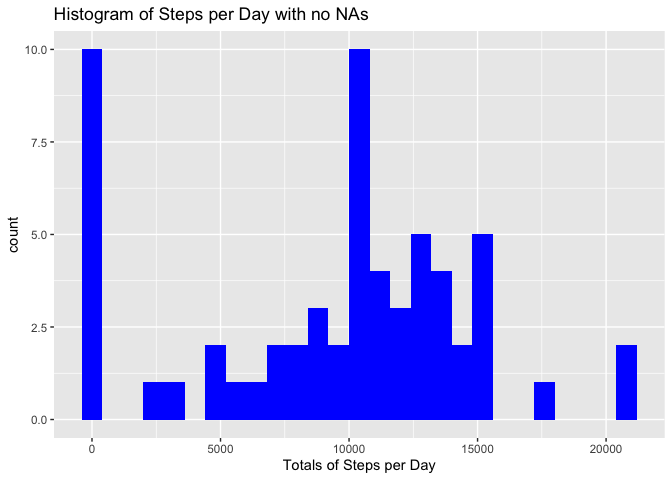

```r
data_full_steps<- aggregate(steps ~ date, data_full, FUN=sum)

g2 <- ggplot(data_full_steps, aes(x=steps))
g2 + geom_histogram(binwidth = 800, fill="blue") + labs(x="Totals of Steps per Day",
                                          title="Histogram of Steps per Day with no NAs") +
        theme(legend.position = "none")
```

##Find average and median steps with no NAs

```r
med2 <- mean(data_full_steps$steps)
avg2 <- median(data_full_steps$steps)
```

# *Are there differences in activity patterns between weekdays and weekends?*

## First create a new factor variable in the dataset with two levels – “weekday” and “weekend” and add to data frame

```r
library(lubridate)
library(gridExtra)
data_full$day<- wday(data_full$date, label=T)
data_full$day_type<- ifelse(data_full$day %in% c("Sat","Sun"), "weekend", "weekday")
head(data_full)
```

```
##   steps       date interval day day_type
## 1     0 2012-10-01        0 Mon  weekday
## 2     0 2012-10-01        5 Mon  weekday
## 3     0 2012-10-01       10 Mon  weekday
## 4     0 2012-10-01       15 Mon  weekday
## 5     0 2012-10-01       20 Mon  weekday
## 6     0 2012-10-01       25 Mon  weekday
```

```r
data_week <- subset(data_full, data_full$day_type=="weekday")
data_weekend <- subset(data_full, data_full$day_type=="weekend")

steps_per_interval_week <- aggregate(steps ~ interval, data_week, FUN=mean)
steps_per_interval_weekend <- aggregate(steps ~ interval, data_weekend, FUN=mean)
```

## Here is a panel plot containing a time series plot of the 5-minute interval and the average number of steps taken, averaged across all weekday days or weekend days

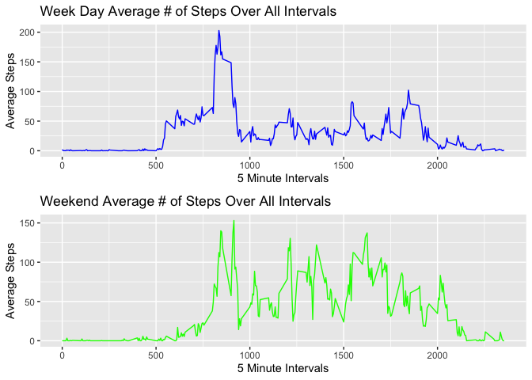

```r
g3 <- ggplot(steps_per_interval_week, aes(x=interval, y=steps))
g3 <-g3 + geom_line(col="blue") + labs(x="5 Minute Intervals", y="Average Steps",
                                          title="Week Day Average # of Steps Over All Intervals")
g4 <- ggplot(steps_per_interval_weekend, aes(x=interval, y=steps))
g4 <-g4 + geom_line(col="green") + labs(x="5 Minute Intervals", y="Average Steps",
                                 title="Weekend Average # of Steps Over All Intervals")

grid.arrange(g3, g4, nrow=2, ncol=1)
```